# Entropia_w_obrazach_132307

### TIMKOD Kamil Pluciński 132307

```python
from PIL import Image
import numpy as np
from matplotlib import pyplot as plt
from pylab import rcParams
import seaborn as sns
from ipywidgets import interact
import numpy as np
import seaborn as sns
import matplotlib.pyplot as plt
import pandas as pd
from tqdm.notebook import tqdm
from PIL import Image
import requests
from io import BytesIO

%matplotlib inline
sns.set_style('dark')
rcParams['figure.figsize'] = 12, 8

def entropy(signal):
        '''
        function returns entropy of a signal
        signal must be a 1-D numpy array
        '''
        lensig=signal.size
        symset=list(set(signal))
        propab=[np.size(signal[signal==i])/(1.0*lensig) for i in symset]
        ent=np.sum([p*np.log2(1.0/p) for p in propab])
        return ent

def entropy_heatmap(image, k=5):
    '''
    image: 2d numpy array as an input
    k (int) : number of neighbours
    '''
    S=image.shape
    E=np.array(image)
    for row in range(S[0]):
        for col in range(S[1]):
            Lx=np.max([0,col-k])
            Ux=np.min([S[1],col+k+1]) # +1 due to x[a:b] -> [a;b)
            Ly=np.max([0,row-k])
            Uy=np.min([S[0],row+k+1])
            region=image[Ly:Uy,Lx:Ux].flatten()
            E[row,col]=entropy(region)
    return E
```

### Zadanie 1

Przeanalizujemy jak zmienia się entropia, gdy wartości pikseli przyporządkujemy do kubełków o różnych rozmiarach. Intuicyjnie jest to sposób na uśrednianie danych, więc spodziewamy się redukcji szumu a tym samym entropii

[figure not shown]

```python
url ='https://unsplash.com/photos/rN78O6UgdkE/download?force=true&w=240' # resize żeby przyspieszyć obliczenia
img = Image.open(BytesIO(requests.get(url).content))
img
```

```python
greyIm = np.array(img.convert('L'))
greyIm.shape
```

```
(160, 240)
```

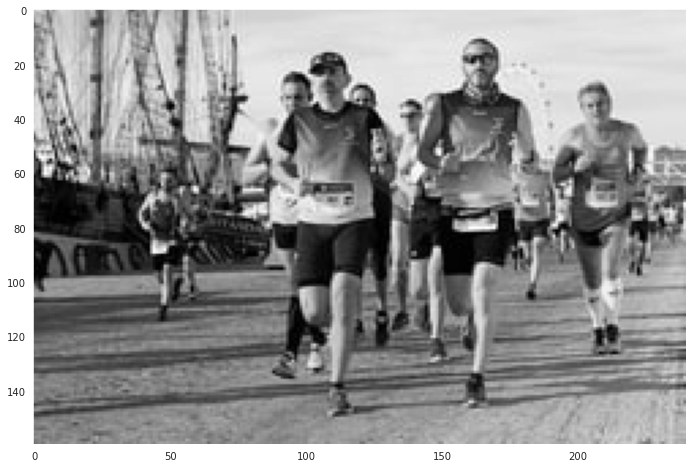

```python
plt.imshow(greyIm, cmap='gray')
```

```python
def digitize(image, bins=10):
    _, bin_edges = np.histogram([0,255], bins=bins)
    digitized = np.digitize(image, bin_edges)
    return digitized
```

```python
heat_maps_ex1 = [
    (
        values_in_bin,
        neighbours,
        entropy_heatmap(digitize(greyIm, bins=255//values_in_bin), k=neighbours)
    )
    for neighbours in tqdm(range(1,6)) for values_in_bin in [1,4,10,25]
]
```

```python
df_1 = pd.DataFrame(heat_maps_ex1, columns=['Bin width', 'Neighbours', 'Heat map'])
df_1['Average entropy'] = df_1['Heat map'].apply(np.mean)
df_1.head()
```

|  | Bin width | Neighbours | Heat map | Average entropy |
| --- | --- | --- | --- | --- |
| 0 | 1 | 1 | [[2, 2, 2, 2, 2, 2, 2, 2, 2, 2, 2, 2, 1, 1, 2,... | 2.305417 |
| 1 | 4 | 1 | [[2, 2, 2, 1, 2, 2, 2, 1, 2, 2, 2, 1, 1, 1, 1,... | 1.766589 |
| 2 | 10 | 1 | [[1, 1, 1, 2, 2, 2, 2, 1, 2, 1, 0, 0, 0, 0, 1,... | 1.269427 |
| 3 | 25 | 1 | [[1, 1, 1, 1, 1, 1, 1, 1, 0, 0, 0, 0, 0, 0, 0,... | 0.647526 |
| 4 | 1 | 2 | [[2, 3, 3, 3, 3, 3, 3, 3, 3, 3, 3, 3, 3, 3, 3,... | 3.589609 |

```python
def f1_func(neighbours):
    plot_df = df_1[df_1['Neighbours']==neighbours]
    plot_df = plot_df.reset_index()
    number_of_images = len(plot_df)
    f, axes = plt.subplots(int(np.ceil(number_of_images/2)), 2)
    for index, row in plot_df.iterrows():
        ax = axes[index//2, index%2]
        im = ax.imshow(row['Heat map'], cmap=plt.cm.jet)
        ax.set_title(f'Entropy heat map, bin width={row["Bin width"]}')
        f.colorbar(im, ax=ax)
    plt.show()
interact(f1_func, neighbours=(1,5))
```

```
<function __main__.f1_func(neighbours)>
```

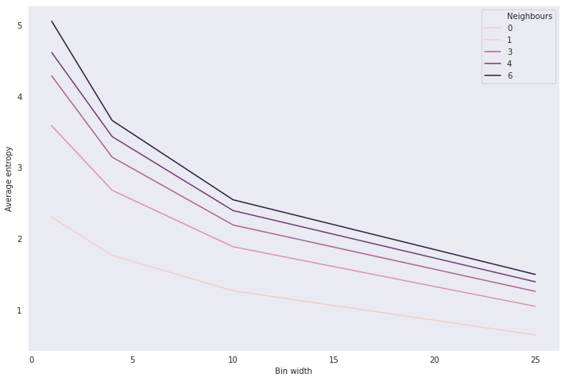

```python
sns.lineplot(data=df_1, x='Bin width', y='Average entropy', hue='Neighbours')
```

```python
df_1['Neighbours'].unique() # chyba błąd z legendą na poziomie samej bilbioteki, wartości wyglądają poprawnie
```

```
array([1, 2, 3, 4, 5])
```

Wyniki potwierdzają wcześniejsze przypuszczenia - większe upraszczanie obrazka (większa ilość wartości w kubełku) powoduje spadek entropii, tak samo jak w przypadku zmniejszania ilości sąsiadów. Intuicyjnie, zmniejszając rozmiar sąsiedztwa różnorodność/szum danych będzie mniejszy, można spodziewać się niższej entropii dla mniejszego k.